# Data Cleaning

## 1.Handling Missing Values

### Fill missing Vaslues with Mean and Median

```python
import pandas as pd
import warnings
warnings.filterwarnings("ignore")


# Create a sample DataFrame with missing values
data = {'Name': ['Alice', 'Bob','Alice', 'Charlie', None],
        'Age': [25, None,25, 30, 22],
        'Salary': [50000, 60000, 50000,None, 70000]}
df = pd.DataFrame(data)
df
```

|  | Name | Age | Salary |
| --- | --- | --- | --- |
| 0 | Alice | 25.0 | 50000.0 |
| 1 | Bob | NaN | 60000.0 |
| 2 | Alice | 25.0 | 50000.0 |
| 3 | Charlie | 30.0 | NaN |
| 4 | None | 22.0 | 70000.0 |

```python
# Check for missing values
print("Before handling missing values:\n", df.isnull())
```

```
Before handling missing values:
     Name    Age  Salary
0  False  False   False
1  False   True   False
2  False  False   False
3  False  False    True
4   True  False   False
```

```python
df.info()
```

```
<class 'pandas.core.frame.DataFrame'>
RangeIndex: 5 entries, 0 to 4
Data columns (total 3 columns):
 #   Column  Non-Null Count  Dtype
---  ------  --------------  -----
 0   Name    4 non-null      object
 1   Age     4 non-null      float64
 2   Salary  4 non-null      float64
dtypes: float64(2), object(1)
memory usage: 248.0+ bytes
```

## fillna()

```python
df['Name'].fillna('Chris',inplace=True)
df
```

|  | Name | Age | Salary |
| --- | --- | --- | --- |
| 0 | Alice | 25.0 | 50000.0 |
| 1 | Bob | NaN | 60000.0 |
| 2 | Alice | 25.0 | 50000.0 |
| 3 | Charlie | 30.0 | NaN |
| 4 | Chris | 22.0 | 70000.0 |

```python
# Handle missing values (e.g., using mean or median)
df['Age'].fillna(df['Age'].mean(), inplace=True)
df['Salary'].fillna(df['Salary'].median(), inplace=True)

# Verify the changes
print("\nAfter handling missing values:\n", df)
```

```
After handling missing values:
       Name   Age   Salary
0    Alice  25.0  50000.0
1      Bob  25.5  60000.0
2    Alice  25.0  50000.0
3  Charlie  30.0  55000.0
4    Chris  22.0  70000.0
```

```python
 df.isnull().sum()
```

```
Name      0
Age       0
Salary    0
dtype: int64
```

## dropna()

```python
data1 = {'Name': ['Alice', 'Bob', None],
        'Age': [25,23, None],
        'Salary': [50000, 60000,None]}
df1 = pd.DataFrame(data1)
print(df1)
df1.dropna() # Applying dropna()
```

```
    Name   Age   Salary
0  Alice  25.0  50000.0
1    Bob  23.0  60000.0
2   None   NaN      NaN
```

|  | Name | Age | Salary |
| --- | --- | --- | --- |
| 0 | Alice | 25.0 | 50000.0 |
| 1 | Bob | 23.0 | 60000.0 |

## Forward Fill Method

```python
import pandas as pd

# Creating a sample data frame
data = {'Date': ['2023-01-01', '2023-01-02', '2023-01-03', '2023-01-04'],
        'Value': [10, None, 15, None]}
df = pd.DataFrame(data)

# Displaying the original data frame
print("Original Data Frame:")
print(df)

# Using forward fill method to fill missing values
df['Value'].fillna(method='ffill', inplace=True)

# Displaying the data frame after forward fill
print("\nData Frame after Forward Fill:")
print(df)
```

```
Original Data Frame:
         Date  Value
0  2023-01-01   10.0
1  2023-01-02    NaN
2  2023-01-03   15.0
3  2023-01-04    NaN

Data Frame after Forward Fill:
         Date  Value
0  2023-01-01   10.0
1  2023-01-02   10.0
2  2023-01-03   15.0
3  2023-01-04   15.0
```

## Backward Fill Method

```python
import pandas as pd

# Creating a sample data frame
data = {'Date': ['2023-01-01', '2023-01-02', '2023-01-03', '2023-01-04'],
        'Value': [10, None, None, 15]}
df = pd.DataFrame(data)

# Displaying the original data frame
print("Original Data Frame:")
print(df)

# Using forward fill method to fill missing values
df['Value'].fillna(method='backfill', inplace=True)

# Displaying the data frame after forward fill
print("\nData Frame after Forward Fill:")
print(df)
```

```
Original Data Frame:
         Date  Value
0  2023-01-01   10.0
1  2023-01-02    NaN
2  2023-01-03    NaN
3  2023-01-04   15.0

Data Frame after Forward Fill:
         Date  Value
0  2023-01-01   10.0
1  2023-01-02   15.0
2  2023-01-03   15.0
3  2023-01-04   15.0
```

```python
import pandas as pd

# Creating a sample data frame
data = {'Date': ['2023-01-01', '2023-01-02', '2023-01-03', '2023-01-04'],
        'Value': [None, 12, 15, None]}
df = pd.DataFrame(data)

# Displaying the original data frame
print("Original Data Frame:")
print(df)

# Using forward fill and then backward fill method to fill missing values
df['Value'].fillna(method='ffill', inplace=True)
df['Value'].fillna(method='bfill', inplace=True)

# Displaying the data frame after fill
print("\nData Frame after Forward and Backward Fill:")
print(df)
```

```
Original Data Frame:
         Date  Value
0  2023-01-01    NaN
1  2023-01-02   12.0
2  2023-01-03   15.0
3  2023-01-04    NaN

Data Frame after Forward and Backward Fill:
         Date  Value
0  2023-01-01   12.0
1  2023-01-02   12.0
2  2023-01-03   15.0
3  2023-01-04   15.0
```

Handling Missing Values:

1. Q: What is a missing value in a dataset?

A: A missing value is a placeholder for data that is not recorded or unavailable in a dataset, often represented as NaN (Not a Number) in Python.

1. Q: How can missing values be handled in a DataFrame in pandas?

A: Missing values in a DataFrame can be handled using methods like fillna, dropna, ffill, and bfill in pandas.

1. Q: What does the fillna method in pandas do?

A: The fillna method is used to fill missing values in a DataFrame with a specified value or using various filling strategies.

1. Q: How does the dropna method work?

A: The dropna method removes rows containing missing values from a DataFrame, effectively reducing the size of the dataset.

1. Q: What is forward fill (ffill) in the context of handling missing values?

A: Forward fill (ffill) fills missing values with the preceding non-missing value along the specified axis (row or column).

1. Q: How is backward fill (bfill) different from forward fill?

A: Backward fill (bfill) fills missing values with the next non-missing value along the specified axis.

1. Q: Can you specify a value to replace missing values using fillna?

A: Yes, with the fillna method, you can replace missing values with a specified constant or a calculated value. df_filled = df.fillna(-1) Replace missing values with -1.

1. Q: When might you choose to drop rows with missing values using dropna?

A: Rows with missing values might be dropped when the missing data is not critical to the analysis, and retaining complete cases is preferred.

1. Q: In what scenarios is forward fill (ffill) more appropriate than backward fill (bfill)?

A: Forward fill (ffill) is more appropriate when the missing values are expected to have the same or similar values as the preceding data points.

1. Q: How can you fill missing values with the mean of the column using fillna?

A: To fill missing values with the mean of a column, you can use df['column'].fillna(df['column'].mean(), inplace=True) in pandas.

1. Q: When is it appropriate to use mean() to fill missing values?

A: Mean() is suitable when the data is normally distributed and missing values are randomly distributed across the dataset. It provides a balanced approach by considering the overall central tendency of the data.

1. Q: In what situations is median() preferable over mean() for filling missing values?

A: Median() is more robust in the presence of outliers, making it suitable when the data contains extreme values. It is less affected by outliers compared to mean().

1. Q: When should std (standard deviation) be used to fill missing values?

A: Std can be used when the variation in the data is an important factor. Filling missing values with std may be appropriate when you want to capture the spread or dispersion of the data.

1. Q: What is the significance of mode() in filling missing values, and when is it appropriate?

A: Mode() is useful for categorical data. It is appropriate when dealing with categorical variables to fill missing values with the most frequently occurring category.

1. Q: When might a custom imputation method be more suitable than mean(), median(), or mode()?

A: A custom imputation method could be more suitable when the missing data has a specific pattern or structure that can be better captured by a domain-specific or context-specific approach.

1. Q: How does the choice between mean() and median() impact imputation in the presence of skewed data?

A: In the presence of skewed data, median() is often preferred as it is less affected by extreme values, providing a better representation of the central tendency compared to mean().

1. Q: Under what circumstances should interpolation or extrapolation be considered for filling missing values?

A: Interpolation is suitable when missing values follow a trend within the existing data, while extrapolation is appropriate when the missing values extend beyond the observed data range.

1. Q: In time series data, when is it appropriate to use the forward-fill or backward-fill method for imputation?

A: Forward-fill is suitable when missing values should be filled with the most recent available value, while backward-fill is appropriate when missing values should be filled with the next available value in the time series.

1. Q: Can I fill missing values based on the mean of neighboring columns?

A: Yes, you can fill missing values using the mean of neighboring columns df_filled_neighbor_mean = df.T.fillna(df.mean(axis=1)).T

1. Q: What challenges might arise from dropping all rows with missing values using the dropna method?

A: Dropping all rows with missing values may lead to a loss of valuable information and may introduce bias if the missing data is not completely random.

1. Q: Why is it important to handle missing values in a dataset?

A: Handling missing values is crucial because they can lead to biased or inaccurate analyses. Ignoring missing data may result in skewed results and can impact the performance of machine learning models.

1. Q: Explain the difference between fillna and dropna methods in pandas.

A: The fillna method is used to fill missing values with a specified constant or through various filling strategies, while the dropna method removes entire rows or columns containing missing values from the DataFrame.

1. Q: When might you choose to use forward fill (ffill) instead of backward fill (bfill)?

A: Forward fill (ffill) is appropriate when the missing values are expected to be similar to the preceding values, such as in time series data where values tend to persist.

1. Q: How can you handle missing values by filling them with the mean of a column in pandas?

A: You can use the fillna method with the mean of the column, like this: df['column'].fillna(df['column'].mean(), inplace=True).

1. Q: What challenges might arise from dropping all rows with missing values using the dropna method?

A: Dropping all rows with missing values may lead to a loss of valuable information and may introduce bias if the missing data is not completely random.

1. Q: In what situations would you consider using interpolation methods to handle missing values?

A: Interpolation methods, like ffill and bfill, are useful when missing values have a logical order or pattern, such as in time series data or spatial datasets.

1. Q: How can you handle missing values in a categorical variable?

A: For categorical variables, you can fill missing values with the mode (most frequent category) using the fillna method or create a new category to represent missing values.

1. Q: What are some potential pitfalls of filling missing values with the mean of a variable?

A: Filling missing values with the mean may introduce bias if the missing values are not missing completely at random. Additionally, it may not be suitable for variables with skewed distributions.

1. Q: Explain the concept of imputation in the context of handling missing values.

A: Imputation is the process of replacing missing values with estimated values based on the available information. It can involve statistical methods or machine learning algorithms to predict missing values.

1. Q: How do you assess the impact of handling missing values on the overall dataset?

A: Assessing the impact involves comparing descriptive statistics, distributions, or model performance before and after handling missing values. It's important to ensure that the imputation method aligns with the data characteristics and analysis goals.

1. Mean():

Suitability: Suitable for normally distributed data with random missing values. Considerations: Sensitive to outliers; may not be the best choice for skewed data.

1. Median():

Suitability: Robust to outliers, suitable for skewed data. Considerations: Ignores the magnitude of values; may not represent the central tendency accurately for normally distributed data.

1. Std (Standard Deviation):

Suitability: Captures variation in data; can be useful for understanding data spread. Considerations: Sensitive to outliers; may not be appropriate for non-normally distributed data.

1. Mode():

Suitability: Appropriate for categorical data; fills missing values with the most frequent category. Considerations: Limited to categorical variables; may not capture nuances in continuous data.

1. Custom Imputation:

Suitability: Useful when data has a specific pattern or structure; domain-specific or context-specific approaches. Considerations: Requires domain knowledge; may be time-consuming to implement.

1. Interpolation/Extrapolation:

Suitability: Interpolation for filling missing values within observed data trends; extrapolation for values beyond the observed range. Considerations: Assumes a certain data continuity; may not perform well with abrupt changes.

1. Forward-fill/Backward-fill (Time Series):

Suitability: Forward-fill for using the most recent available value; backward-fill for using the next available value. Considerations: Appropriate for time series data; may not capture trends if time order is not meaningful.

## 2. Removing Duplicates:

```python
# Check for duplicate rows
print("Before removing duplicates:\n", df.duplicated())
```

```
Before removing duplicates:
 0    False
1    False
2    False
3    False
dtype: bool
```

```python
# Remove duplicate rows
df.drop_duplicates(inplace=True)

# Verify the changes
print("\nAfter removing duplicates:\n", df)
```

```
After removing duplicates:
          Date  Value
0  2023-01-01   12.0
1  2023-01-02   12.0
2  2023-01-03   15.0
3  2023-01-04   15.0
```

## 3.Polynomial Interpolation

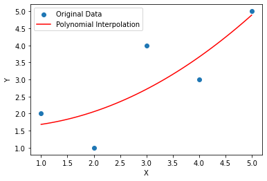

```python
import numpy as np
import matplotlib.pyplot as plt

# Example data
x_known = np.array([1, 2, 3, 4, 5])
y_known = np.array([2, 1, 4, 3, 5])

coefficients = np.polyfit(x_known, y_known, 2) # a polynomial of degree 2
polynomial = np.poly1d(coefficients) #np.poly1d creates a polynomial function based on the coefficients.


# Generate x values for the interpolation
x_interpolated = np.linspace(1, 5, 100)

# Use the polynomial function to get interpolated y values
y_interpolated = polynomial(x_interpolated)

# Plot the original data and the interpolated values
plt.scatter(x_known, y_known, label='Original Data')
plt.plot(x_interpolated, y_interpolated, label='Polynomial Interpolation', color='red')
plt.xlabel('X')
plt.ylabel('Y')
plt.legend()
plt.show()
```

```python
x_prediction = 4
y_prediction = polynomial(x_prediction)

print(f'The predicted y value at x = {x_prediction} is {y_prediction:.2f}')
```

```
The predicted y value at x = 4 is 3.66
```

## 4.Linear Interpolation

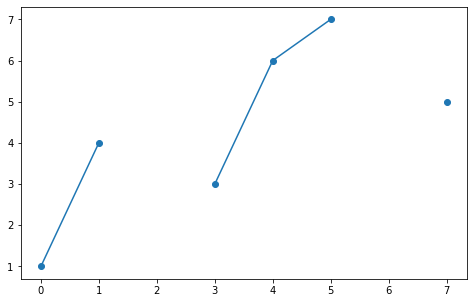

```python
# Create a DataFrame with missing values
data = {'A': [1, 4, None, 3,6,7,None, 5]}
df = pd.DataFrame(data)

# Plot the original data
plt.figure(figsize=(8, 5))
plt.plot(df['A'], marker='o', linestyle='-', label='Original Data')
```

```python
# Linear interpolation for missing values in a DataFrame
df['A_interpolated'] = df['A'].interpolate(method='linear')
df['A_interpolated']
```

```
0    1.0
1    4.0
2    3.5
3    3.0
4    6.0
5    7.0
6    6.0
7    5.0
Name: A_interpolated, dtype: float64
```

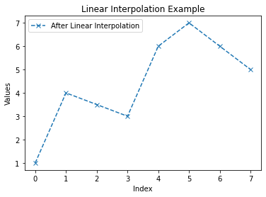

```python
# Plot the data after linear interpolation
plt.plot(df['A_interpolated'], marker='x', linestyle='--', label='After Linear Interpolation')

plt.xlabel('Index')
plt.ylabel('Values')
plt.title('Linear Interpolation Example')
plt.legend()
plt.show()
```

```python
index_to_predict = 7
predicted_value = df.at[index_to_predict, 'A_interpolated'] #df.at accessor is used to access a single value for a row/column label pair.
predicted_value                                             #index_to_predict is the row label (index) you want to access, which is set to 8.
                                                            #A_interpolated' is the column label you want to access, which corresponds to the column containing the linearly interpolated values.
#plt.scatter(index_to_predict, predicted_value, color='red', label=f'Predicted Value at Index {index_to_predict}')

# Add labels and legend
```

```
5.0
```

## Multiple imputation Technique

Multiple imputation is a statistical technique used to handle missing data by creating multiple sets of plausible values for the missing observations. Rather than imputing a single value for each missing data point, multiple imputation recognizes and accounts for the uncertainty associated with the imputation process. This method provides more accurate estimates of the parameters and standard errors in statistical analyses compared to single imputation methods.

```python
import numpy as np
from fancyimpute import IterativeImputer

# Example data with missing values
data = np.array([[1, 2, np.nan],
                 [4, np.nan, 6],
                 [7, 8, 9]])

# Initialize the IterativeImputer with desired parameters
imputer = IterativeImputer(max_iter=20, random_state=0)
# max_iter is the maximum number of imputation iterations, and random_state is used for reproducibility.

# Perform multiple imputation
imputed_data = imputer.fit_transform(data)
#fit_transform method to perform multiple imputations on the data. The imputed data is stored in the imputed_data variable.

# Print the original and imputed data
print("Original Data:")
print(data)
print("\nImputed Data:")
print(imputed_data)
```

[output not shown]

## 3. Outlier Detection and Handling:

Z_Score= X-mean/std X is the individual data point, Mean-Mean is the average of all data points, and Standard Deviation-Standard Deviation measures how spread out the values are.

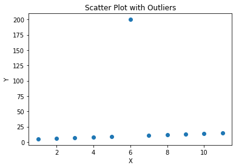

```python
import numpy as np
import matplotlib.pyplot as plt

# Create a DataFrame with outliers
data = {'X': [1, 2, 3, 4, 5, 6, 7, 8, 9, 10, 11],
        'Y': [5, 6, 7, 8, 9, 200, 11, 12, 13, 14, 15]}
df = pd.DataFrame(data)

# Visualize the data with a scatter plot
plt.scatter(df['X'], df['Y'])
plt.title('Scatter Plot with Outliers')
plt.xlabel('X')
plt.ylabel('Y')
plt.show()
```

```python
from scipy.stats import zscore

# Calculate z-scores for the 'Y' column
df['Z_Score'] = np.abs(zscore(df['Y']))

df
```

|  | X | Y | Z_Score |
| --- | --- | --- | --- |
| 0 | 1 | 5 | 0.407086 |
| 1 | 2 | 6 | 0.388808 |
| 2 | 3 | 7 | 0.370531 |
| 3 | 4 | 8 | 0.352254 |
| 4 | 5 | 9 | 0.333976 |
| 5 | 6 | 200 | 3.156991 |
| 6 | 7 | 11 | 0.297422 |
| 7 | 8 | 12 | 0.279144 |
| 8 | 9 | 13 | 0.260867 |
| 9 | 10 | 14 | 0.242590 |
| 10 | 11 | 15 | 0.224313 |

```python
# Set a threshold for outlier detection (e.g., z-score > 3)
threshold = 3
outliers = df[df['Z_Score'] > threshold]
outliers
```

|  | X | Y | Z_Score |
| --- | --- | --- | --- |
| 5 | 6 | 200 | 3.156991 |

```python
# Handle outliers by replacing with the mean
mean_value = df['Y'].mean()
mean_value
```

```
27.272727272727273
```

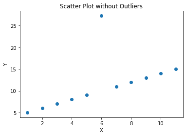

```python
df['Y'] = np.where(df['Z_Score'] > threshold, mean_value, df['Y'])

# Drop the z-score column used for detection
df = df.drop(columns=['Z_Score'])

# Visualize the data after handling outliers
plt.scatter(df['X'], df['Y'])
plt.title('Scatter Plot without Outliers')
plt.xlabel('X')
plt.ylabel('Y')
plt.show()
```

### Remove Outlier

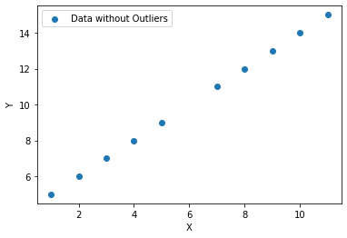

```
Original DataFrame:
     X    Y
0    1    5
1    2    6
2    3    7
3    4    8
4    5    9
5    6  200
6    7   11
7    8   12
8    9   13
9   10   14
10  11   15

DataFrame without outliers:
     X   Y
0    1   5
1    2   6
2    3   7
3    4   8
4    5   9
6    7  11
7    8  12
8    9  13
9   10  14
10  11  15
```

```python
import numpy as np
import pandas as pd
import matplotlib.pyplot as plt
from scipy.stats import zscore

# Create a DataFrame with outliers
data = {'X': [1, 2, 3, 4, 5, 6, 7, 8, 9, 10, 11],
        'Y': [5, 6, 7, 8, 9, 200, 11, 12, 13, 14, 15]}
df = pd.DataFrame(data)

# Calculate Z-scores for each column
z_scores = zscore(df)

# Set a threshold for identifying outliers (e.g., 3 standard deviations)
threshold = 3

# Identify outliers
outliers = np.abs(z_scores) > threshold

# Remove outliers from the DataFrame
df_no_outliers = df[~outliers.any(axis=1)]

# Plot the original and modified data
plt.scatter(df_no_outliers['X'], df_no_outliers['Y'], label='Data without Outliers')
plt.xlabel('X')
plt.ylabel('Y')
plt.legend()
plt.show()

print("Original DataFrame:")
print(df)
print("\nDataFrame without outliers:")
print(df_no_outliers)
```

1. Q: What is an outlier in a dataset?

A: An outlier is an observation that deviates significantly from the other observations in a dataset, often indicating a rare or abnormal occurrence.

1. Q: Why is it important to detect and handle outliers in a dataset?

A: Outliers can distort statistical analyses, affect model performance, and lead to incorrect conclusions. Handling outliers is essential for obtaining accurate and robust results.

1. Q: What are some common methods for detecting outliers?

A: Common methods for detecting outliers include statistical techniques such as z-scores, the interquartile range (IQR), and visualization methods like box plots and scatter plots.

1. Q: How does the z-score method work in outlier detection?

A: The z-score measures how many standard deviations an observation is from the mean. Observations with high z-scores (beyond a certain threshold) are considered outliers.

1. Q: How do you handle outliers once they are detected?

A: Outliers can be removed from the dataset if they are identified as errors or anomalies that would negatively impact the analysis or transforming them using techniques replacing outliers with the mean, median.

1. Q: What is the impact of outliers on machine learning models?

A: Outliers can have a significant impact on machine learning models by influencing model parameters and predictions. Robust models are less sensitive to outliers, but some models may be adversely affected.

1. Q: Can you mention a machine learning algorithm that is sensitive to outliers?

A: Linear regression is an example of a machine learning algorithm sensitive to outliers. Outliers can disproportionately influence the slope and intercept of the regression line.

1. Q: When might it be inappropriate to remove outliers from a dataset?

A: It might be inappropriate to remove outliers when they represent valid and meaningful information, such as rare events or extreme conditions that are relevant to the analysis.

1. Q: How can visualization techniques help in identifying outliers?

A: Visualization techniques, such as box plots and scatter plots, provide a visual representation of the data distribution. Outliers are often visually apparent as points that fall far from the bulk of the data points.

## Common techniques

```python
import pandas as pd
import numpy as np

# Create a sample dataset
data = {
    'Name': ['John', 'Alice', 'Bob', 'Charlie', 'David'],
    'Age': [25, np.nan, 30, 35, 40],
    'Salary': [50000, 60000, 75000, np.nan, 90000],
    'Gender': ['Male', 'Female', 'Male', 'Male', 'Male'],
    'City': ['New York', 'Paris', 'London', 'Berlin', 'Tokyo']
}

df = pd.DataFrame(data)
print("Original Dataset:")
print(df)
```

```
Original Dataset:
      Name   Age   Salary  Gender      City
0     John  25.0  50000.0    Male  New York
1    Alice   NaN  60000.0  Female     Paris
2      Bob  30.0  75000.0    Male    London
3  Charlie  35.0      NaN    Male    Berlin
4    David  40.0  90000.0    Male     Tokyo
```

```python
df.info()
```

```
<class 'pandas.core.frame.DataFrame'>
RangeIndex: 5 entries, 0 to 4
Data columns (total 5 columns):
 #   Column  Non-Null Count  Dtype
---  ------  --------------  -----
 0   Name    5 non-null      object
 1   Age     4 non-null      float64
 2   Salary  4 non-null      float64
 3   Gender  5 non-null      object
 4   City    5 non-null      object
dtypes: float64(2), object(3)
memory usage: 328.0+ bytes
```

```python
# Fill missing values in 'Age' with the mean of both 'Age' and 'Salary'
df['Age'].fillna(df['Age'].mean(), inplace=True)
df['Salary'].fillna(df['Salary'].median(), inplace=True)
df
```

|  | Name | Age | Salary | Gender | City |
| --- | --- | --- | --- | --- | --- |
| 0 | John | 25.0 | 50000.0 | Male | New York |
| 1 | Alice | 32.5 | 60000.0 | Female | Paris |
| 2 | Bob | 30.0 | 75000.0 | Male | London |
| 3 | Charlie | 35.0 | 67500.0 | Male | Berlin |
| 4 | David | 40.0 | 90000.0 | Male | Tokyo |

```python
#Convert Data Types:
# Convert Age column to integer
df['Age'] = df['Age'].astype(int)
df
```

|  | Name | Age | Salary | Gender | City |
| --- | --- | --- | --- | --- | --- |
| 0 | John | 25 | 50000.0 | Male | New York |
| 1 | Alice | 32 | 60000.0 | Female | Paris |
| 2 | Bob | 30 | 75000.0 | Male | London |
| 3 | Charlie | 35 | 67500.0 | Male | Berlin |
| 4 | David | 40 | 90000.0 | Male | Tokyo |

```python
#Rename Columns:
#Rename the 'Salary' column to 'Income'
df.rename(columns={'Salary': 'Income'}, inplace=True)
df
```

|  | Name | Age | Income | Gender | City |
| --- | --- | --- | --- | --- | --- |
| 0 | John | 25 | 50000.0 | Male | New York |
| 1 | Alice | 32 | 60000.0 | Female | Paris |
| 2 | Bob | 30 | 75000.0 | Male | London |
| 3 | Charlie | 35 | 67500.0 | Male | Berlin |
| 4 | David | 40 | 90000.0 | Male | Tokyo |

```python
# Remove outliers
# Remove outliers in the 'Income' column
df = df[df['Income'] < 80000]
df
```

|  | Name | Age | Income | Gender | City |
| --- | --- | --- | --- | --- | --- |
| 0 | John | 25 | 50000.0 | Male | New York |
| 1 | Alice | 32 | 60000.0 | Female | Paris |
| 2 | Bob | 30 | 75000.0 | Male | London |
| 3 | Charlie | 35 | 67500.0 | Male | Berlin |

```python
# Convert 'Gender' column to uppercase
df['Gender'] = df['Gender'].str.upper()
df
```

|  | Name | Age | Income | Gender | City |
| --- | --- | --- | --- | --- | --- |
| 0 | John | 25 | 50000.0 | MALE | New York |
| 1 | Alice | 32 | 60000.0 | FEMALE | Paris |
| 2 | Bob | 30 | 75000.0 | MALE | London |
| 3 | Charlie | 35 | 67500.0 | MALE | Berlin |

```python
# Keep only the first occurrence of each person (based on 'Name')
# Standardize the 'City' names to lowercase
df['City'] = df['City'].str.lower()
df
```

|  | Name | Age | Income | Gender | City |
| --- | --- | --- | --- | --- | --- |
| 0 | John | 25 | 50000.0 | MALE | new york |
| 1 | Alice | 32 | 60000.0 | FEMALE | paris |
| 2 | Bob | 30 | 75000.0 | MALE | london |
| 3 | Charlie | 35 | 67500.0 | MALE | berlin |

```python
# Remove leading and trailing whitespaces in 'City' column
df['City'] = df['City'].str.strip()
df
```

|  | Name | Age | Income | Gender | City |
| --- | --- | --- | --- | --- | --- |
| 0 | John | 25 | 50000.0 | MALE | new york |
| 1 | Alice | 32 | 60000.0 | FEMALE | paris |
| 2 | Bob | 30 | 75000.0 | MALE | london |
| 3 | Charlie | 35 | 67500.0 | MALE | berlin |

```python
# Create age bins and categorize individuals
bins = [0, 25, 35, 50]
labels = ['Young', 'Adult', 'Senior']
df['Age_Category'] = pd.cut(df['Age'], bins=bins, labels=labels) #pd.cut is used to create the 'Age_Category' column based on the specified bins and labels.
df
```

|  | Name | Age | Income | Gender | City | Age_Category |
| --- | --- | --- | --- | --- | --- | --- |
| 0 | John | 25 | 50000.0 | MALE | new york | Young |
| 1 | Alice | 32 | 60000.0 | FEMALE | paris | Adult |
| 2 | Bob | 30 | 75000.0 | MALE | london | Adult |
| 3 | Charlie | 35 | 67500.0 | MALE | berlin | Adult |

```python
# Concatenate 'Name' and 'City' columns to create a new 'Location' column
df['Location'] = df['Name'] + ', ' + df['City']
df
```

|  | Name | Age | Income | Gender | City | Age_Category | Location |
| --- | --- | --- | --- | --- | --- | --- | --- |
| 0 | John | 25 | 50000.0 | MALE | new york | Young | John, new york |
| 1 | Alice | 32 | 60000.0 | FEMALE | paris | Adult | Alice, paris |
| 2 | Bob | 30 | 75000.0 | MALE | london | Adult | Bob, london |
| 3 | Charlie | 35 | 67500.0 | MALE | berlin | Adult | Charlie, berlin |

```python
# Convert 'Income' to thousands for consistency
df['Income'] = df['Income'] / 1000
df
```

|  | Name | Age | Income | Gender | City | Age_Category | Location |
| --- | --- | --- | --- | --- | --- | --- | --- |
| 0 | John | 25 | 50.0 | MALE | new york | Young | John, new york |
| 1 | Alice | 32 | 60.0 | FEMALE | paris | Adult | Alice, paris |
| 2 | Bob | 30 | 75.0 | MALE | london | Adult | Bob, london |
| 3 | Charlie | 35 | 67.5 | MALE | berlin | Adult | Charlie, berlin |

```python
# Create a new 'Joining_Date' column with current date
df['Joining_Date'] = pd.to_datetime('today').date()
df
```

|  | Name | Age | Income | Gender | City | Age_Category | Location | Joining_Date |
| --- | --- | --- | --- | --- | --- | --- | --- | --- |
| 0 | John | 25 | 50.0 | MALE | new york | Young | John, new york | 2023-12-27 |
| 1 | Alice | 32 | 60.0 | FEMALE | paris | Adult | Alice, paris | 2023-12-27 |
| 2 | Bob | 30 | 75.0 | MALE | london | Adult | Bob, london | 2023-12-27 |
| 3 | Charlie | 35 | 67.5 | MALE | berlin | Adult | Charlie, berlin | 2023-12-27 |

```python
# Display the current state of the dataset
print("Intermediate Dataset:")
print(df)
```

```
Intermediate Dataset:
      Name  Age  Income  Gender      City Age_Category         Location  \
0     John   25    50.0    MALE  new york        Young   John, new york
1    Alice   32    60.0  FEMALE     paris        Adult     Alice, paris
2      Bob   30    75.0    MALE    london        Adult      Bob, london
3  Charlie   35    67.5    MALE    berlin        Adult  Charlie, berlin

  Joining_Date
0   2023-12-27
1   2023-12-27
2   2023-12-27
3   2023-12-27
```

```python
# Assume 'Joining_Date' column has dates in MM/DD/YYYY format, convert to YYYY-MM-DD
df['Joining_Date'] = pd.to_datetime(df['Joining_Date'], format='%m/%d/%Y', errors='coerce')
df
```

|  | Name | Age | Income | Gender | City | Age_Category | Location | Joining_Date |
| --- | --- | --- | --- | --- | --- | --- | --- | --- |
| 0 | John | 25 | 50.0 | MALE | new york | Young | John, new york | NaT |
| 1 | Alice | 32 | 60.0 | FEMALE | paris | Adult | Alice, paris | NaT |
| 2 | Bob | 30 | 75.0 | MALE | london | Adult | Bob, london | NaT |
| 3 | Charlie | 35 | 67.5 | MALE | berlin | Adult | Charlie, berlin | NaT |

```python
# Assume 'Location' column contains redundant city information, extract unique city names
df['City'] = df['Location'].apply(lambda x: x.split(', ')[-1])
df
```

|  | Name | Age | Income | Gender | City | Age_Category | Location | Joining_Date |
| --- | --- | --- | --- | --- | --- | --- | --- | --- |
| 0 | John | 25 | 50.0 | MALE | new york | Young | John, new york | NaT |
| 1 | Alice | 32 | 60.0 | FEMALE | paris | Adult | Alice, paris | NaT |
| 2 | Bob | 30 | 75.0 | MALE | london | Adult | Bob, london | NaT |
| 3 | Charlie | 35 | 67.5 | MALE | berlin | Adult | Charlie, berlin | NaT |

1. Question: What is data cleaning, and why is it important in the context of data analysis and machine learning?

Answer: Data cleaning is the process of identifying and correcting errors or inconsistencies in a dataset. It is crucial for ensuring that the data is accurate, reliable, and suitable for analysis or model training. Clean data is essential for obtaining meaningful insights and building robust machine learning models.

1. Question: What are some common types of errors that may require attention during data cleaning?

Answer: Common types of errors include missing values, duplicate records, inaccurate entries, inconsistent formatting, and outliers. Addressing these issues is necessary to maintain the integrity of the dataset.

1. Question: How do you handle missing data during the data cleaning process?

Answer: Handling missing data can involve methods such as removing rows with missing values, imputing missing values with statistical measures (e.g., mean, median), or using more advanced imputation techniques such as K-nearest neighbors.

1. Question: Why is it important to identify and handle duplicate records in a dataset?

Answer: Duplicate records can introduce bias and skew analysis or modeling results. Identifying and handling duplicates ensures that each data point is unique, preventing duplication of information and maintaining the accuracy of analyses.

1. Question: What role does outlier detection play in data cleaning?

Answer: Outliers can significantly impact statistical measures and model performance. Outlier detection helps identify and address data points that deviate significantly from the majority, ensuring that they don't unduly influence analysis or modeling.

1. Question: How can inconsistent formatting in categorical data be addressed during data cleaning?

Answer: Inconsistent formatting in categorical data can be standardized by converting text to lowercase, removing leading or trailing spaces, and ensuring consistent naming conventions. This helps avoid misinterpretation of categories and improves data quality.

1. Question: When is it appropriate to use data imputation methods in data cleaning?

Answer: Data imputation is used when dealing with missing values. Imputation methods fill in missing values with estimated or calculated values, enabling the retention of valuable information in the dataset.

1. Question: What challenges might arise when cleaning textual data, and how can they be addressed?

Answer: Challenges in cleaning textual data include handling stopwords, stemming or lemmatization, and addressing typos. These challenges can be addressed through text preprocessing techniques such as removing stopwords, applying stemming or lemmatization, and implementing spell-checking procedures.

1. Question: Why is it essential to check for and handle inconsistent data types during data cleaning?

Answer: Inconsistent data types can lead to errors in analysis or modeling. Checking and ensuring consistent data types across features help maintain data integrity and prevent issues arising from incompatible data.

1. Question: How does data cleaning contribute to the overall success of a data science project?

Answer: Data cleaning is a critical step in the data science pipeline as it ensures the reliability and accuracy of the data. Clean data leads to more accurate analyses, better insights, and improved machine learning model performance, ultimately contributing to the success of a data science project.

1. Question: What is the significance of handling inconsistent or incorrect data entry formats in data cleaning?

Answer: Inconsistent or incorrect data entry formats can lead to misinterpretation of data and errors in analysis. Data cleaning involves standardizing formats to ensure uniformity and accuracy in the dataset.

1. Question: How can you identify and handle outliers during the data cleaning process? Answer: Outliers can be identified using statistical methods such as Z-score or the interquartile range (IQR). Handling outliers may involve removing them, transforming them, or using robust statistical measures to reduce their impact.
2. Question: Why is it important to assess and address the quality of categorical data during data cleaning?

Answer: Quality issues in categorical data, such as misspelled categories or inconsistent labels, can lead to misinterpretation. Data cleaning involves standardizing and validating categorical data to ensure accuracy and reliability in analyses.

1. Question: What role does data profiling play in the initial stages of data cleaning?

Answer: Data profiling involves summarizing and understanding the structure and characteristics of a dataset. In the context of data cleaning, profiling helps identify potential issues such as missing values, outliers, and inconsistent formatting.

1. Question: When should you consider using data imputation techniques in data cleaning?

Answer: Data imputation is necessary when dealing with missing values in a dataset. Instead of discarding incomplete records, imputation methods are applied to estimate and fill in missing values, allowing the retention of valuable information.

1. Question: How can data cleaning contribute to improving the accuracy of machine learning models?

Answer: Data cleaning ensures that the input data used for model training is accurate and free from errors. This, in turn, improves the accuracy of machine learning models by providing a reliable foundation for learning patterns and making predictions.

1. Question: What challenges may arise when dealing with time-series data during the data cleaning process?

Answer: Challenges in time-series data cleaning include handling missing values over time, addressing irregular time intervals, and managing seasonality. Specialized techniques, such as interpolation or resampling, may be used to overcome these challenges.

1. Question: How does data cleaning contribute to maintaining data privacy and security?

Answer: Data cleaning may involve anonymizing or removing personally identifiable information (PII) to protect privacy. Cleaning also helps in identifying and rectifying any security vulnerabilities or risks associated with the data.

1. Question: In what ways can data cleaning impact the efficiency of downstream data processing tasks?

Answer: Clean data facilitates more efficient downstream tasks, such as analysis, modeling, and reporting. Eliminating errors and inconsistencies reduces the likelihood of processing delays and ensures that subsequent tasks are performed more smoothly.

1. Question: Why is it crucial to document the data cleaning steps taken in a project?

Answer: Documentation of data cleaning steps is essential for transparency and reproducibility. It allows others to understand the transformations applied to the data, making it easier to reproduce analyses and ensuring the reliability of results.

1. Question: What is the difference between data cleaning and data validation?

Answer: Data cleaning involves identifying and correcting errors or inconsistencies in the dataset, while data validation focuses on ensuring that the data meets specific quality standards or business rules. Both are crucial for maintaining data integrity.

1. Question: How does data cleaning contribute to enhancing the interpretability of analytical results?

Answer: Clean data ensures that the results of data analyses are more accurate and reliable. This, in turn, enhances the interpretability of the findings, making it easier for stakeholders to make informed decisions based on trustworthy information.

1. Question: Why is it important to establish a data cleaning pipeline in a data science project?

Answer: Establishing a data cleaning pipeline streamlines the process of identifying and correcting issues in the dataset. A well-defined pipeline ensures consistency in data cleaning steps, making it easier to reproduce results and maintain data quality.

1. Question: What role does domain knowledge play in effective data cleaning?

Answer: Domain knowledge is crucial for understanding the context of the data and recognizing potential errors or outliers that may not be apparent through statistical methods alone. It helps in making informed decisions during the data cleaning process.

1. Question: How can data cleaning contribute to the prevention of biased analyses and model outcomes?

Answer: Addressing issues such as missing data or outliers during data cleaning helps prevent biases in analyses and model training. A clean dataset reduces the risk of biased results that may arise from inaccuracies or skewed representations.

1. Question: When is data imputation more suitable than removing missing values during data cleaning?

Answer: Data imputation is more suitable when the missing values are not random, and there is valuable information in the incomplete records. Removing missing values may result in loss of critical data, especially in scenarios where missingness carries meaning.

1. Question: What are some tools and techniques commonly used for automating data cleaning processes?

Answer: Tools like OpenRefine, Trifacta, and Pandas (in Python) offer functionalities for automating data cleaning tasks. Techniques include scripting, regular expressions, and machine learning-based approaches for identifying and correcting errors.

1. Question: In what ways can data cleaning contribute to improved data visualization outcomes?

Answer: Clean data is essential for accurate and meaningful data visualizations. Data cleaning ensures that visualizations accurately represent the underlying patterns in the data, leading to more insightful and actionable visual insights.

1. Question: How can data cleaning be integrated into an iterative data science workflow?

Answer: Data cleaning is often an iterative process that occurs alongside data exploration and analysis. As insights are gained, additional cleaning steps may be identified and applied. Integrating data cleaning iteratively ensures ongoing improvement in data quality throughout the project.

1. Question: How can missing values be handled in a DataFrame in pandas?

Answer: Missing values in a DataFrame can be handled using methods like fillna, dropna, ffill, and bfill in pandas.